# SMDM Europe Worked Examples

# Basic Outline

Can translate the below into learning objectives.

## Morning: “Bottom Up”

1. Fit a mortality model and construct a simple “alive-dead” model that replicates life table data.
2. Add in a CVD sick state and replicate overall life-expectancy.
3. Add in a cause-specific (CVD) death state using cause-deleted life tables and cause-specific mortality rate. Verify that it replicates overall life expectancy.
4. Using the “Healthy-CVD-Dead” natural history model, count up the total number who become sick. Show how standard conversion formulas will miscount the total number who become ill.

## Afternoon: “Top Down”

5. Start with the HIV model from the Briggs textbook. Solve for the continuous generator matrix.
6. Fit a mortality model to German life table data and swap in an age-specific death rate into the HIV monotherapy model. How do modeled costs and QALYs differ?
7. Suppose there is a new combination therapy with a hazard ratio and 95% confidence interval. Incorporate this into the HIV model and calculate ICERs.
8. Now solve for the PSA distribution parameters for this new hazard ratio.
9. Use copulas to simulate correlated direct medical care and community care costs.

# Questions and To-Do

- [Shawn] In our appendix example, we have a two-cycle tunnel state (T1 and T2) once you become ill. We allow for exits to background mortality from T1, but everyone in T2 exits to the receiving bucket “N”. I assume we don’t need exits to background mortality because we’re only using these for accounting purposes – but if it’s for a transient utility decrement, don’t we only need to apply the utility decrement to the non-decedents within T2?
- [Shawn] Need the optimization algorithm to solve for PSA parameters that minimizes:

$$(F(x_1) - p_1)^2 + (F(x_2)-p_2)^2$$

- [Shawn]. Can we also add analytic solution code for lognormal and logistic? Or just rely on the optimization?
- [All] Do we need a full-fledged CEA for the CVD model? Or would just creating the natural history model suffice?
- [Astrid] The [life table data](https://ghdx.healthdata.org/record/ihme-data/gbd-2019-life-tables-1950-2019) at the global burden of disease website is split into different files for different age buckets. Can we download these files and aggretate them together to get a full life table for each country/region/year combo?
- [Astrid] Perhaps we could create a Shiny app that does the above?
  - Input: country/region and year
  - Output 1: Constructed life table
  - Output 2: Parameters for mortality model

# 0. Setup

We begin by specifying a parameter object that will ultimately guide the discrete time model.

```r
params <- list(
  n_age_init = 55,
  n_age_max = 65,
  d_c = 0.03,
  d_e = 0.03,
  n_sim = 1000,
  r_HS = 0.1,
  hr_SD = 1.9, # hazard ratio on rate
  # overall death
  # p_HD is the time-varying background mortality
  # p_SD is the time-varying background mortality * 1.9(Hazard Ratio)
  hr_HS_trt = 0.5,
  u_H = 1,
  u_S = 0.773,
  u_D = 0,
  c_H = 8494, # Non-CVD health care cost
  c_trt = 840,
  c_S = 3917 + 8494, # Cost of annual follow-up post ASCVD
  c_nonfatal_firstYr = 49348,
  c_fatal_firstYr = 16760,
  c_D = 0,
  cycle_length = 1,
  n_cycles = 10
)

v_names_states = c("Healthy", "Sick", "Death")
n_states = length(v_names_states)
v_names_str = c("quo","trt")
n_strategies = length(v_names_str)
```

# 1. Mortality Modeling (Alive-Dead)

## Estimate a mortality model to parameterize background mortality.

Background mortality will be based on a mortality model. This reduces the parameterization from the total number of age bins in the life table data to only a few parameters that can be used to characterize background mortality.

Next we construct a life table from these data. This is done using the `demography` package.

```r
#############################################
# Define Parameters for Life Table Modeling
#############################################
mort_year =  # Year to obtain from Human Mortality Database
  2019
N = # Population basis for life table
  100000
max_age =  # Max age in life table
  99
min_age =  # Min age in life table
  0
n_cycles =  # Number of discrete time (annual) cycles in Markov
  100

###############################
# Underlying Life-Table Data
###############################

lt <-  # Read in the U.S. life table data from the human mortality database.
  read_rds(here("_sandbox/mortality/usa-life-table.rds")) %>%
  lifetable(.,series = "total", years = mort_year) %>%
  as_tibble() %>%
  mutate_at(vars(lx,dx), function(x) x*N) %>%
  mutate(country = "USA") %>%
  mutate(age = x)

lt %>%
  ungroup() %>%
  select(-x) %>%
  select(country,age,everything()) %>%
  head() %>%
  kable() %>%
  kable_styling()
```

| country | age | year | mx | qx | lx | dx | Lx | Tx | ex |
| --- | --- | --- | --- | --- | --- | --- | --- | --- | --- |
| USA | 0 | 2019 | 0.00556 | 0.00553 | 100000 | 553.221 | 0.99482 | 78.963 | 78.963 |
| USA | 1 | 2019 | 0.00038 | 0.00038 | 99447 | 38.180 | 0.99428 | 77.968 | 78.402 |
| USA | 2 | 2019 | 0.00023 | 0.00023 | 99409 | 23.160 | 0.99397 | 76.974 | 77.432 |
| USA | 3 | 2019 | 0.00018 | 0.00018 | 99385 | 17.689 | 0.99377 | 75.980 | 76.450 |
| USA | 4 | 2019 | 0.00014 | 0.00014 | 99368 | 14.209 | 0.99361 | 74.986 | 75.463 |
| USA | 5 | 2019 | 0.00013 | 0.00013 | 99354 | 13.213 | 0.99347 | 73.993 | 74.474 |

The columns here are

- `age`: Ages for lifetable
- `year`: Period years or cohort years
- `mx`: Death rate at age x.
- `qx`: The probability that an individual of exact age x will die before exact age x+1.
- `lx`: Number of survivors to exact age x. This is defined relative to a **radix**, or the size of a cohort from which the life table is derived).
- `dx`: The number of deaths between exact ages x and x+1.
- `Lx`: Number of years lived between exact age x and exact age x+1.
- `Tx`: Number of years lived after exact age x.
- `ex`: Remaining life expectancy at exact age x.

Our next step is to fit a mortality model to these data. Generally speaking, we need three inputs:

- `age`: Ages for lifetable
- `dx`: The number of deaths between exact ages x and x+1.
- `lx`: Number of survivors to exact age x. This is defined relative to a **radix**, or the size of a cohort from which the life table is derived).

The `MortalityLaws` package has a *number* of mortality models we can draw from. Table 1 summarizes these.

```r
laws <- availableLaws()
laws$table %>%
  arrange(TYPE) %>%
  kable() %>%
  kable_styling()
```

Table 1: Mortality Models in MortalityLaws package

| YEAR | NAME | MODEL | TYPE | CODE | FIT | SCALE_X |
| --- | --- | --- | --- | --- | --- | --- |
| 1870 | Opperman | mu[x] = A/sqrt(x) - B + C*sqrt(x) | 1 | opperman | mu[x] | FALSE |
| 1939 | Weibull | mu[x] = 1/sigma * (x/M)^(M/sigma - 1) | 1 | weibull | mu[x] | FALSE |
| NA | Inverse-Gompertz | mu[x] = [1- exp(-(x-M)/sigma)] / [exp(-(x-M)/sigma) - 1] | 2 | invgompertz | mu[x] | TRUE |
| NA | Inverse-Weibull | mu[x] = 1/sigma * (x/M)^[-M/sigma - 1] / [exp((x/M)^(-M/sigma)) - 1] | 2 | invweibull | mu[x] | TRUE |
| 1825 | Gompertz | mu[x] = A exp[Bx] | 3 | gompertz | mu[x] | TRUE |
| NA | Gompertz | mu[x] = 1/sigma * exp[(x-M)/sigma)] | 3 | gompertz0 | mu[x] | TRUE |
| 1860 | Makeham | mu[x] = A exp[Bx] + C | 3 | makeham | mu[x] | TRUE |
| NA | Makeham | mu[x] = 1/sigma * exp[(x-M)/sigma)] + C | 3 | makeham0 | mu[x] | TRUE |
| 1932 | Perks | mu[x] = [A + BC^x] / [BC^-x + 1 + DC^x] | 3 | perks | mu[x] | TRUE |
| 1960 | Strehler-Mildvan | mu[x] = K * exp[-V0 * (1 - Bx)/D] | 3 | strehler_mildvan | mu[x] | TRUE |
| 1943 | Van der Maen | mu[x] = A + Bx + Cx^2 + I/[N - x] | 4 | vandermaen | mu[x] | TRUE |
| 1971 | Beard | mu[x] = A exp(Bx) / [1 + KA exp(Bx)] | 4 | beard | mu[x] | TRUE |
| 1971 | Beard-Makeham | mu[x] = A exp(Bx) / [1 + KA exp(Bx)] + C | 4 | beard_makeham | mu[x] | TRUE |
| 1979 | Gamma-Gompertz | mu[x] = A exp(Bx) / (1 + AG/B * [exp(Bx) - 1]) | 4 | ggompertz | mu[x] | TRUE |
| 1943 | Van der Maen | mu[x] = A + Bx + I/[N - x] | 5 | vandermaen2 | mu[x] | TRUE |
| NA | Quadratic | mu[x] = A + Bx + Cx^2 | 5 | quadratic | mu[x] | TRUE |
| 1998 | Kannisto | mu[x] = A exp(Bx) / [1 + A exp(Bx)] | 5 | kannisto | mu[x] | TRUE |
| 1998 | Kannisto-Makeham | mu[x] = A exp(Bx) / [1 + A exp(Bx)] + C | 5 | kannisto_makeham | mu[x] | TRUE |
| 1871 | Thiele | mu[x] = A exp(-Bx) + C exp[-.5D (x-E)^2] + F exp(Gx) | 6 | thiele | mu[x] | FALSE |
| 1883 | Wittstein | q[x] = (1/B) A^-[(Bx)^N] + A^-[(M-x)^N] | 6 | wittstein | q[x] | FALSE |
| 1979 | Siler | mu[x] = A exp(-Bx) + C + D exp(Ex) | 6 | siler | mu[x] | FALSE |
| 1980 | Heligman-Pollard | q[x]/p[x] = A^[(x + B)^C] + D exp[-E log(x/F)^2] + G H^x | 6 | HP | q[x] | FALSE |
| 1980 | Heligman-Pollard | q[x] = A^[(x + B)^C] + D exp[-E log(x/F)^2] + GH^x / [1 + GH^x] | 6 | HP2 | q[x] | FALSE |
| 1980 | Heligman-Pollard | q[x] = A^[(x + B)^C] + D exp[-E log(x/F)^2] + GH^x / [1 + KGH^x] | 6 | HP3 | q[x] | FALSE |
| 1980 | Heligman-Pollard | q[x] = A^[(x + B)^C] + D exp[-E log(x/F)^2] + GH^(x^K) / [1 + GH^(x^K)] | 6 | HP4 | q[x] | FALSE |
| 1983 | Rogers-Planck | q[x] = A0 + A1 exp[-Ax] + A2 exp[B(x - u) - exp(-C(x - u))] + A3 exp[Dx] | 6 | rogersplanck | q[x] | FALSE |
| 1987 | Martinelle | mu[x] = [A exp(Bx) + C] / [1 + D exp(Bx)] + K exp(Bx) | 6 | martinelle | mu[x] | FALSE |
| 1992 | Carriere | l[x] = P1 l[x](weibull) + P2 l[x](invweibull) + P3 l[x](gompertz) | 6 | carriere1 | q[x] | TRUE |
| 1992 | Carriere | l[x] = P1 l[x](weibull) + P2 l[x](invgompertz) + P3 l[x](gompertz) | 6 | carriere2 | q[x] | TRUE |
| 1992 | Kostaki | q[x]/p[x] = A^[(x+B)^C] + D exp[-(E_i log(x/F_))^2] + G H^x | 6 | kostaki | q[x] | FALSE |

Because we want to stay general (i.e., model all over the age spectrum), our first attempt will be a Gompertz model.

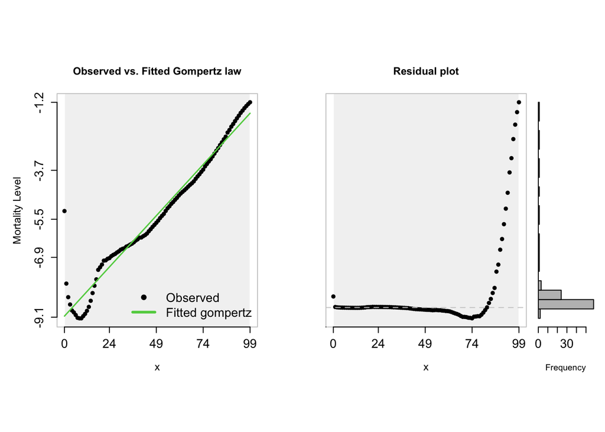

Gompertz doesn’t fit all age ranges well—particularly young ages. This is a well-known fact. If we were to focus only on adults, however, this would be a nice way to go.

Here, for example, is a Gompertz model fit to 40 year old adults:

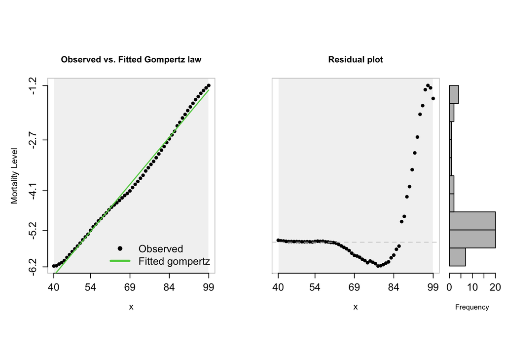

The nice thing about this is that it summarizes age-specific mortality in terms of just two parameters. We can then feed these parameters into the `gompertz()` formula to yield a death rate for a given age. Here is the mortality rate at age 75 for an initial population of 40 year olds:

```r
MortalityLaws::gompertz(x = 75 - 40, coef(gom_fit40))
```

```
$hx
[1] 0.030479

$par
        A         B
0.0014654 0.0867125

$Sx
[1] 0.71563
```

For this exercise we want to stay general, so let’s select an alternative model that can better fit the entire age range. To get a sense of the options, let’s select the models that are designed for the entire age range and see their fit:

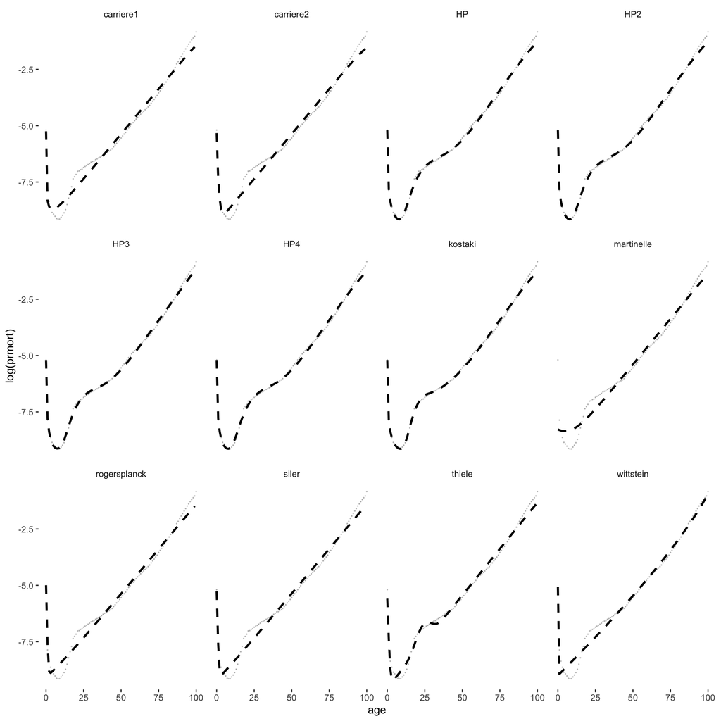

Figure 1: Fitted mortality rate vs. observed rate, by model

Here we see that some do better than others. We’ll choose the HP2 (Heligman-Bollard) to fit, though note that any well-fitting mortality model can be used because there is a mapping of the fitted parameters to the mortality rate for each (see Table 1). The `MortalityLaws` package also has a function for each, much like the `gompertz()` function above. For our selected model, the function is `HP2()`.

Let’s add the fitted mortality model parameters to our overall parameter list object. We’ll include gompertz , too, just for comparison later.

```r
params <- modifyList(params,list(heligman_bollard = coef(hp_fit),
                                 gompertz = coef(gom_fit)))
```

## Verify that a discrete time Markov model can replicate life-expectancy at age X.

Now we’ll answer the question: can we replicate life expectancy based on a life table using a discrete time Markov model?

To do this, we’ll consruct a very simple two-state discrete time Markov model. We’ll then parameterize the model with the coefficients from the mortality models above, and then calculate life expectancy with a QALY “payoff” of 1.0 if alive and no discounting.

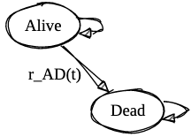

Let’s start with a cohort of 40 year olds. Based on the life table, we should expect these individuals to live an additional 41 years

```r
starting_age = 40

tr_ <-  tr_alt_ <- # Start the Markov trace
  bind_rows(c("alive" = 1, "dead" = 0)) %>% mutate(t = 0) %>% select(t,alive,dead)

for (.x in 1:n_cycles) {
    r_death <-
      HP2(.x + starting_age - 1, params$heligman_bollard)$hx

    ## Embedded Transition Probability Matrix
    m_Q <- # construct the transtiion rate matrix (2x2 for alive-dead)
        matrix(
            c(-(r_death), r_death, 0, 0),
            byrow = TRUE,
            ncol = 2,
            dimnames = list(c("alive", "dead"), c("alive", "dead"))
        )
    m_P <- # embed the transition probability matrix
        expm(m_Q)

    p_death <- 1 - exp(-r_death)

    ## Alternative version using standard rate-to-probability conversion formulas
    m_P_ <-
      matrix(c((1 - p_death),p_death,0,1), byrow=TRUE,
             ncol=2,
             dimnames = list(c("alive","dead"),c("alive","dead")))

    tmp_ <-  # current state occupancy
      c(tr_[.x, "alive"], tr_[.x, "dead"]) %>% unlist()

    tr_ <- # add next row of the Markov trace
        bind_rows(
            tr_,
            (tmp_ %*% m_P)  %>%
              as.matrix() %>%
              data.frame() %>%
              mutate(t = .x) %>%
              dplyr::select(t, alive, dead)
        )

    tmp_ <-  # current state occupancy
      c(tr_alt_[.x, "alive"], tr_alt_[.x, "dead"]) %>% unlist()

    tr_alt_ <- # add next row of the Markov trace
        bind_rows(
            tr_alt_,
            (tmp_ %*% m_P_)  %>%
              as.matrix() %>%
              data.frame() %>%
              mutate(t = .x) %>%
              dplyr::select(t, alive, dead)
        )

}

# Cycle adjustment
cycle_adj <-
    c(rep(c(4/3,2/3),n_cycles/2),1/3)
cycle_adj[1] <- 1/3

# Life-Expectancy via the discrete time Markov
payoff_lifeexp <- c(1,0)

life_exp_markov <-
    t(cycle_adj) %*% tr_$alive

life_exp_markov_alt <-
    t(cycle_adj) %*% tr_alt_$alive

# Life-Expectancy via the life table
life_exp_lifetable <-
  lt %>% filter(age==starting_age) %>% pull(ex)

tibble(markov = as.vector(life_exp_markov),
       markov_alt = as.vector(life_exp_markov_alt),life_table = life_exp_lifetable) %>%
  kable(digits = 2) %>%
  kable_styling()
```

| markov | markov_alt | life_table |
| --- | --- | --- |
| 40.73 | 40.73 | 41 |

We’ll now loop through various starting ages to verify that we can replicate life expectancy with a simple discrete time Markov model.

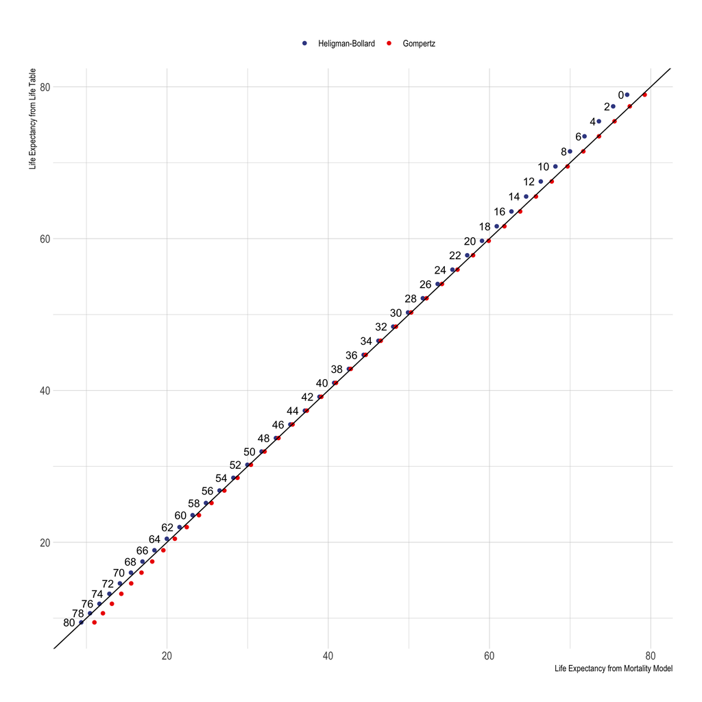

Figure 2: Comparison of Modeled Life Expectancy from Mortality Models to Life Expectancy from Life Table

# 2. Incorporating a Disease State (Healthy-Sick-Dead)

## Split “Alive” health state into healthy vs. sick

Let’s now expand our simple model to include a “sick” state. For now we’ll assume you’re either healthy or sick, but that being sick does not confer a higher mortality rate:

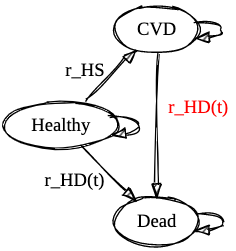

## Verify that a discrete time Markov model can replicate life-expectancy at age X.

Starting with a cohort aged 40, can we successfully replicate life expectancy again?

```r
starting_age = .x = 40

tr_ <- tr_alt_ <-
  bind_rows(c("healthy" = 1, "sick" = 0, "dead" = 0)) %>% mutate(t = 0) %>% select(t,healthy,sick,dead)

for (.x in 1:n_cycles) {

   r_death <- HP2(.x + starting_age - 1, params$heligman_bollard)$hx

    # Embedded Version
    m_Q <-
        matrix(
            c(-(r_death + params$r_HS), params$r_HS, r_death,
                0, -(r_death), r_death,
              0,0,0),
            byrow = TRUE,
            ncol = 3,
            dimnames = list(c("healthy", "sick","dead"), c("healthy", "sick","dead"))
        )

    m_P <-
        expm(m_Q)

    # Using Formulas to Convert
    p_death <- 1 - exp(-r_death)
    p_sick <- 1 - exp(-params$r_HS)

    m_P_ <-
      matrix(c(
       (1-p_death - p_sick), p_sick, p_death,
       0,(1-p_death),p_death,
       0,0,1
      ),
      byrow=TRUE,
      ncol = 3,
            dimnames = list(c("healthy", "sick","dead"), c("healthy", "sick","dead"))
      )

    tmp_ <- c(tr_[.x, "healthy"], tr_[.x, "sick"], tr_[.x, "dead"]) %>% unlist()

    tr_ <-
        bind_rows(
            tr_,
            (tmp_ %*% m_P)  %>% as.matrix() %>% data.frame() %>% mutate(t = .x) %>% select(t,healthy,sick,dead)
        )

    tmp_ <- c(tr_alt_[.x, "healthy"], tr_alt_[.x, "sick"], tr_alt_[.x, "dead"]) %>% unlist()

    tr_alt_ <-
        bind_rows(
            tr_alt_,
            (tmp_ %*% m_P_)  %>% as.matrix() %>% data.frame() %>% mutate(t = .x) %>% select(t,healthy,sick,dead)
        )

}

# Cycle adjustment
cycle_adj <-
    c(rep(c(4/3,2/3),n_cycles/2),1/3)
cycle_adj[1] <- 1/3

# Life-Expectancy via the discrete time Markov
payoff_living <- matrix(c(1,1,0),byrow=TRUE,ncol=1)
living <- as.matrix(tr_[,c("healthy","sick","dead")]) %*% payoff_living
living_alt <- as.matrix(tr_alt_[,c("healthy","sick","dead")]) %*% payoff_living

life_exp_markov <-
    t(cycle_adj) %*% living

life_exp_markov_alt <-
    t(cycle_adj) %*% living_alt

# Life-Expectancy via the life table
life_exp_lifetable <-
  lt %>% filter(age==starting_age) %>% pull(ex)

tibble(markov = as.vector(life_exp_markov),
       markov_alt = as.vector(life_exp_markov_alt),life_table = life_exp_lifetable) %>%
  kable(digits = 2) %>%
  kable_styling()
```

| markov | markov_alt | life_table |
| --- | --- | --- |
| 40.73 | 40.73 | 41 |

# 3. Cause-Specific Death

## Show that if we assume a static hazard ratio for death (applied to the secular death rate) we will dramatically understate overall life expectancy.

What happens if we just put in a cause-specific hazard ratio that acts on the background mortality rate?

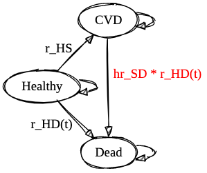

```r
starting_age = .x = 40

tr_ <- tr_alt_ <-
  bind_rows(c("healthy" = 1, "sick" = 0, "dead" = 0)) %>% mutate(t = 0) %>% select(t,healthy,sick,dead)

for (.x in 1:n_cycles) {

   r_death <- HP2(.x + starting_age - 1, params$heligman_bollard)$hx

      # Correct Version
    m_Q <-
        matrix(
            c(-(r_death + params$r_HS), params$r_HS, r_death,
                0, -(r_death * params$hr_S), r_death* params$hr_S,
              0,0,0),
            byrow = TRUE,
            ncol = 3,
            dimnames = list(c("healthy", "sick","dead"), c("healthy", "sick","dead"))
        )

    m_P <-
        expm(m_Q)

    # Using Formulas to Convert
    p_death <- 1 - exp(-r_death)
    p_sick <- 1 - exp(-params$r_HS)
    p_sick_death <- 1 - exp(-(r_death * params$hr_S))

    m_P_ <-
      matrix(c(
       (1-p_death - p_sick), p_sick, p_death,
       0,(1-p_sick_death),p_sick_death,
       0,0,1
      ),
      byrow=TRUE,
      ncol = 3,
            dimnames = list(c("healthy", "sick","dead"), c("healthy", "sick","dead"))
      )

    tmp_ <- c(tr_[.x, "healthy"], tr_[.x, "sick"], tr_[.x, "dead"]) %>% unlist()

    tr_ <-
        bind_rows(
            tr_,
            (tmp_ %*% m_P)  %>% as.matrix() %>% data.frame() %>% mutate(t = .x) %>% select(t,healthy,sick,dead)
        )

    tmp_ <- c(tr_alt_[.x, "healthy"], tr_alt_[.x, "sick"], tr_alt_[.x, "dead"]) %>% unlist()

    tr_alt_ <-
        bind_rows(
            tr_alt_,
            (tmp_ %*% m_P_)  %>% as.matrix() %>% data.frame() %>% mutate(t = .x) %>% select(t,healthy,sick,dead)
        )

}

# Cycle adjustment
cycle_adj <-
    c(rep(c(4/3,2/3),n_cycles/2),1/3)
cycle_adj[1] <- 1/3

# Life-Expectancy via the discrete time Markov
payoff_living <- matrix(c(1,1,0),byrow=TRUE,ncol=1)
living <- as.matrix(tr_[,c("healthy","sick","dead")]) %*% payoff_living
living_alt <- as.matrix(tr_alt_[,c("healthy","sick","dead")]) %*% payoff_living

life_exp_markov <-
    t(cycle_adj) %*% living

life_exp_markov_alt <-
    t(cycle_adj) %*% living_alt

# Life-Expectancy via the life table
life_exp_lifetable <-
  lt %>% filter(age==starting_age) %>% pull(ex)

tibble(markov = as.vector(life_exp_markov),
       markov_alt = as.vector(life_exp_markov_alt),life_table = life_exp_lifetable) %>%
  kable(digits = 2) %>%
  kable_styling()
```

| markov | markov_alt | life_table |
| --- | --- | --- |
| 34.88 | 34.92 | 41 |

We no longer approximate the ‘natural history’ life-expectancy! Uh oh.

## Construct a cause-deleted life table, and use the cause deleted secular deaths instead.

Let’s get an age-specific cause of death data from the [Global Burden of Disease](https://vizhub.healthdata.org/gbd-results/) project.

These data summarize, by age group, the percentage of overall deaths that are attributable to cardiovascular disease.

```r
ihme_cvd <-
  tibble::tribble(
        ~age_name,        ~val,
               1L, 0.038771524,
               5L, 0.038546046,
              10L, 0.044403585,
              15L, 0.033781126,
              20L, 0.035856165,
              25L, 0.053077797,
              30L, 0.086001439,
              35L, 0.130326551,
              40L, 0.184310334,
              45L,  0.21839762,
              50L, 0.243705394,
              55L, 0.256334637,
              60L,  0.26828001,
              65L, 0.272698709,
              70L,  0.28529754,
              75L, 0.310642009,
               0L, 0.016750489,
              80L, 0.353518012,
              85L, 0.399856716,
              90L, 0.447817792,
              95L, 0.495305502
        ) %>%
    mutate(age_ihme = cut(age_name,unique(c(0,1,seq(0,95,5),105)),right=FALSE))  %>%
    select(age_ihme,  pct_cvd = val)
```

We now need to take our life table data and bin it similarly to the IHME data.

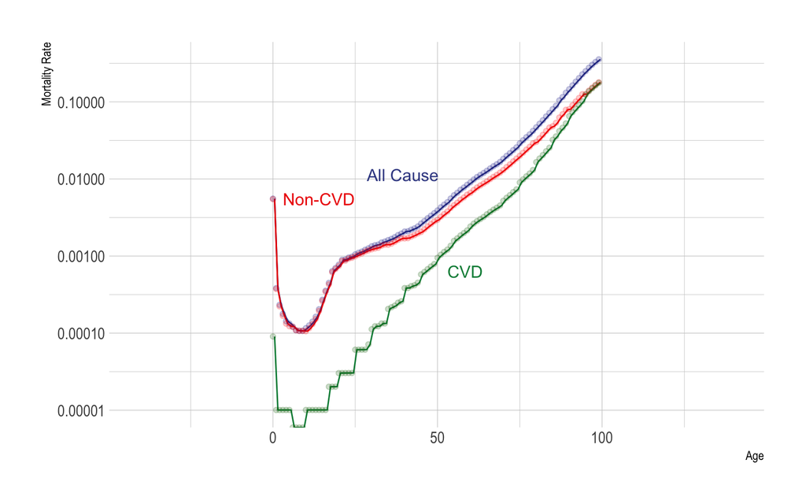

Figure 3: Mortality Rates

```r
# Source: https://grodri.github.io/demography/neoplasms

# The time to death wtihin intervals is drawn from the "a" column here.
# We really only use it for the 0-1 year old age range.
# url = "https://grodri.github.io/datasets/preston41.dat"
# b41 <- read.table(url, header=FALSE)
# names(b41) <- c("age","D","Di","lx","a")

edit.na <- function(x, value) { x[is.na(x)] <- value; x}

lt_ <-
    lt %>%
    mutate(age_ihme = cut(age,unique(c(0,1,seq(0,95,5),105)),right=FALSE)) %>%
    left_join(ihme_cvd,"age_ihme") %>%
    mutate(dx_i = round(dx * pct_cvd)) %>%
    select(age_ihme,
           age,
           D = dx,  # Deaths
           Di = dx_i, # Cause-specific deaths
           lx = lx) %>% # Living
    mutate(a = ifelse(age_ihme == "[0,1)", 0.152, 0.5)) %>%

    # The conditional probability of dying of a given cause given survival to
    # the age group is easy to obtain, we just multiply the overall probability
    # by the ratio of deaths of a given cause to all deaths.

    mutate(q = edit.na(1 - lead(lx)/lx, 1),
           qi = q * Di/D) %>%

    # The unconditional counts of deaths of any cause and of a given cause
    # are calculated multiplying by the number surviving to the start of each
    # age group, which is lx. Recall that to die of cause i in the interval
    # [x, x+n) one must survive all causes up to age x.

    mutate(d = lx * q,
           di = lx * qi) %>%

    # In preparation for the next part, note that if we had nmx and we were willing
    # to assume that the hazard is constant in each age group we would have had a
    # slightly different estimate of the survival function. Let us “back out”
    # the rates from the probabilities:

    mutate(n = c(diff(age),NA),
           m =  edit.na( q/(n - q * (n - a)), 1/tail(a,1))) %>%  # m[last] = 1/a[last]

    # With these rates we compute the cumulative hazard and survival as

    mutate(H = cumsum(n * m),
           S = edit.na(exp(-lag(H)), 1)) %>%  # S[1] = 1

    # We compute cause-specific rates by dividing deaths of a given cause into person-years
    # of exposure, which is equivalent to multiplying the overall rate by the ratio of
    # deaths of a given cause to the total. Here we want deaths for causes other than
    # neoplasms. I will use the subscript d for deleted:

    mutate(Rd = (D - Di)/D,
           md = m * Rd) %>%

    # We compute the conditional probability of surviving an age group after
    # deleting a cause as the overall probability raised to Rd, and then calculate
    # the survival function as a cumulative product

    mutate(pd = (1 - q)^Rd,
           ld = 100000 * cumprod(c(1, pd[-length(pd)]))) %>%

    # Then we construct a survival function in the usual way, but treating this
    # hazard as if it was the only one operating:

    mutate(Hd = cumsum(n * md),
           Sd = edit.na(exp(-lag(Hd)), 1)) %>% # Sd[1] = 1
    mutate(Pd =  edit.na((Sd - lead(Sd))/md, tail(Sd/md, 1))) %>%

  # Now do it for cause-specific death.

  mutate(Ri = Di / D,
         pi = (1 - qi)^Ri,
         li = 100000 * cumprod(c(1, pi[-length(pi)]))) %>%
  mutate(mi = m - md)

bx <- mutate(lt_, agem = age + n/2, mi = m - md)[-nrow(lt_), ]


p_cd <-
  bx %>%
  select(agem,m,md,mi) %>%
  gather(series,value,-agem) %>%
  mutate(series = factor(series,levels = c("m","md","mi"),labels = c("All Cause", "Non-CVD","CVD"))) %>%
  ggplot(aes(x = agem, y = value, colour = series)) + geom_line() + scale_y_log10() +
  ggsci::scale_color_aaas() +
  geom_dl(method = "smart.grid",aes(label=series)) +
  scale_x_continuous(expand = c(0.5,0)) +
  theme(legend.position = "none") +
  labs(x = "Age", y = "Mortality Rate") +
  geom_point(data = lt_ %>% mutate(series = "Life Table") %>% filter(age<100), aes(x = age, y = m), alpha =0.2, colour = "darkblue") +
  geom_point(data = lt_ %>% mutate(series = "Life Table") %>% filter(age<100), aes(x = age, y = md), alpha =0.2, colour = "red") +
  geom_point(data = lt_ %>% mutate(series = "Life Table") %>% filter(age<100), aes(x = age, y = m - md), alpha =0.2, colour = "darkgreen")

p_cd
```

```r
ages_     <- lt_$age[lt_$age<=max_age & lt_$age>=min_age]
deaths_   <- lt_$d[lt_$age<=max_age & lt_$age>=min_age] - lt_$di[lt_$age<=max_age & lt_$age>=min_age]
exposure_  <- lt_$lx[lt_$age<=max_age & lt_$age>=min_age]

hp_fit_ <- MortalityLaw(
                x  = ages_,
                Dx  = deaths_,   # vector with death counts
                Ex  = exposure_, # vector containing exposures
                law = "HP2",
                opt.method = "LF2")
```

## Model using cause-specific death rate from the cause-deleted life table data.

Now let’s construct a model that adds in cause-specific death, and uses cause-deleted (modeled) mortality for secular death:

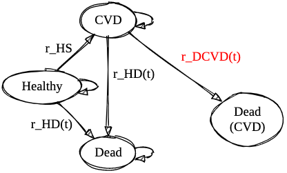

```r
params <- modifyList(params, list(cause_deleted = coef(hp_fit_)))
starting_age = .x = 40

tr_ <- tr_alt_ <-
  bind_rows(c("healthy" = 1, "sick" = 0, "cvddeath" = 0, "dead" = 0)) %>% mutate(t = 0) %>% select(t,healthy,sick,cvddeath,dead)

for (.x in 1:n_cycles) {

   current_age <- min(.x + starting_age - 1,max(lt_$age))

   r_death <- HP2(.x + starting_age - 1, params$cause_deleted)$hx
   r_cause <- lt_ %>% filter(age==current_age) %>% pull(mi)

    # Correct Version
    m_Q <-
        matrix(
            c(-(r_death + params$r_HS), params$r_HS, 0, r_death,
                0, -(r_cause+r_death), r_cause,r_death,
              0,0,0,0,
              0,0,0,0),
            byrow = TRUE,
            ncol = 4,
            dimnames = list( c("healthy", "sick","cvddeath","dead"), c("healthy", "sick","cvddeath","dead"))
        )

    m_P <-
        expm(m_Q)

    # Using Formulas to Convert
    p_death <- 1 - exp(-r_death)
    p_sick <- 1 - exp(-params$r_HS)
    p_sick_death <- 1 - exp(-(r_cause))

    m_P_ <-
      matrix(c(
       (1-p_death - p_sick), p_sick, 0,p_death,
       0,(1-p_sick_death - p_death),p_sick_death,p_death,
       0,0,0,0,
       0,0,0,1
      ),
      byrow=TRUE,
      ncol = 4,
            dimnames = list(c("healthy", "sick","cvddeath","dead"), c("healthy", "sick","cvddeath","dead"))
      )

    tmp_ <- c(tr_[.x, "healthy"], tr_[.x, "sick"], tr_[.x, "cvddeath"],tr_[.x, "dead"]) %>% unlist()

    tr_ <-
        bind_rows(
            tr_,
            (tmp_ %*% m_P)  %>% as.matrix() %>% data.frame() %>% mutate(t = .x) %>% select(t,healthy,sick,cvddeath,dead)
        )

    tmp_ <- c(tr_alt_[.x, "healthy"], tr_alt_[.x, "sick"], tr_alt_[.x, "cvddeath"], tr_alt_[.x, "dead"]) %>% unlist()

    tr_alt_ <-
        bind_rows(
            tr_alt_,
            (tmp_ %*% m_P_)  %>% as.matrix() %>% data.frame() %>% mutate(t = .x) %>% select(t,healthy,sick,cvddeath,dead)
        )

}

# Cycle adjustment
cycle_adj <-
    c(rep(c(4/3,2/3),n_cycles/2),1/3)
cycle_adj[1] <- 1/3

# Life-Expectancy via the discrete time Markov
payoff_living <- matrix(c(1,1,0,0),byrow=TRUE,ncol=1)
living <- as.matrix(tr_[,c("healthy","sick","cvddeath","dead")]) %*% payoff_living
living_alt <- as.matrix(tr_alt_[,c("healthy","sick","cvddeath","dead")]) %*% payoff_living

life_exp_markov <-
    t(cycle_adj) %*% living

life_exp_markov_alt <-
    t(cycle_adj) %*% living_alt

# Life-Expectancy via the life table
life_exp_lifetable <-
  lt %>% filter(age==starting_age) %>% pull(ex)

tibble(markov = as.vector(life_exp_markov),
       markov_alt = as.vector(life_exp_markov_alt),life_table = life_exp_lifetable) %>%
  kable(digits = 2) %>%
  kable_styling()
```

| markov | markov_alt | life_table |
| --- | --- | --- |
| 40.97 | 40.88 | 41 |

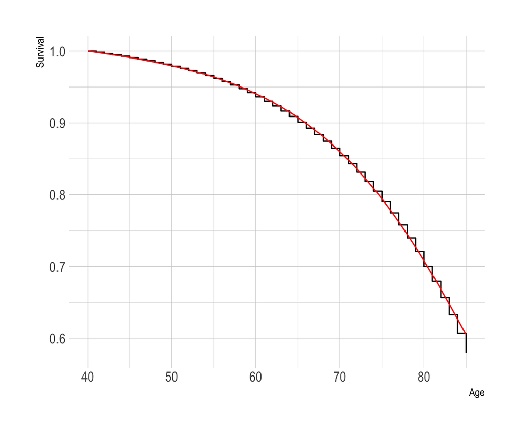

Survival by Age: Discrete Time Markov (Red) vs. Cause-Deleted Life Table (Black)

```r
lt_ %>%
  filter(age>=40) %>%
  mutate(qd = 1 - exp(-md)) %>%
  select(-pd) %>%
  mutate(pd = 1 - qd)   %>%
  mutate(cump = ifelse(row_number()==1,1,lag(cumprod(pd),1)) ) %>%
  select(-lx) %>%
  mutate(lx = N  * cump)  %>%
  mutate(ditest = lx * qd) %>%
  filter(age<=85) %>%
  ggplot(aes(x = age, y = cump)) + geom_step() +
  geom_line(data = tr_ %>% filter(t<=45), aes(x = starting_age + t, y = 1 - dead ), colour = "red") + labs(x = "Age", y = "Survival")
```

Good news: we essentially replicate overall life expectancy! Though note the small difference with the model based on formula conversions rather than embedding.

- Note that we used the cause-deleted life table’s cause-specific mortality rate (`mi`) here. Another alternative would be to use a similar mortality model as above – but in practice, for CVD deaths this does not yield good predictions for old ages (see plot )

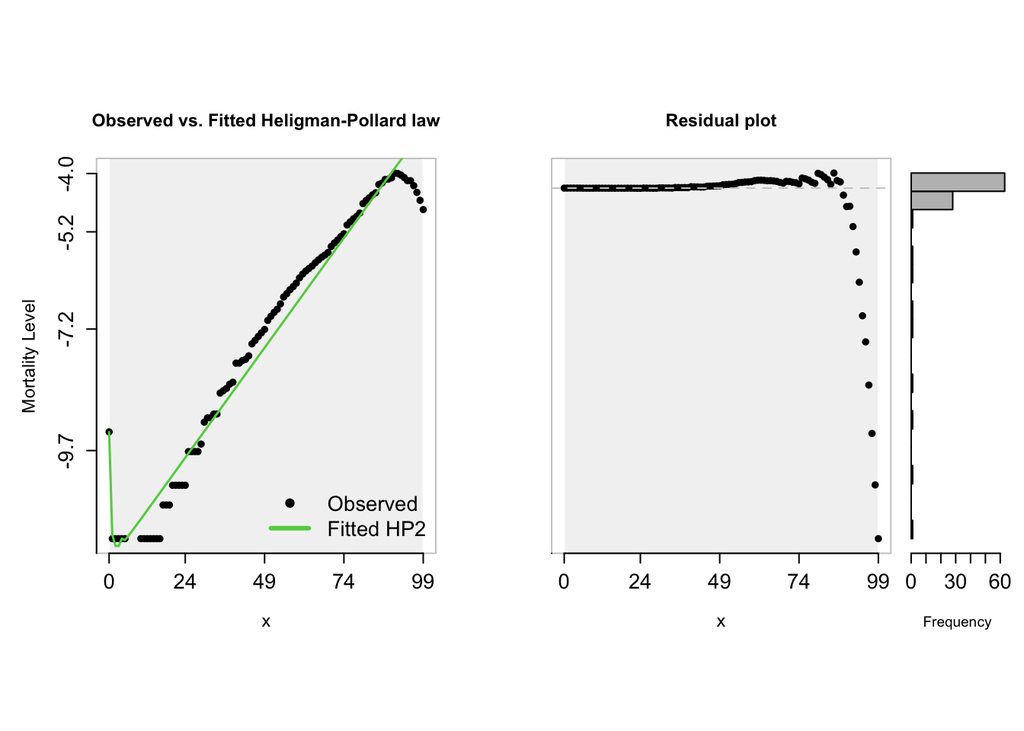

```r
ages_     <- lt_$age[lt_$age<=max_age & lt_$age>=min_age]
deaths_i   <- lt_$di[lt_$age<=max_age & lt_$age>=min_age]
exposure_i  <- lt_$li[lt_$age<=max_age & lt_$age>=min_age]

hp_fit_i <- MortalityLaw(
                x  = ages_,
                Dx  = deaths_i,   # vector with death counts
                Ex  = exposure_i, # vector containing exposures
                law = "HP2",
                opt.method = "LF2")

params <- modifyList(params, list(cause_deleted = coef(hp_fit_),
                                  cause_specific = coef(hp_fit_i)))

plot(hp_fit_i)
```

# 4. Ensuring Accurate Counts, Costs and QALYs

## Count the number who become ill under various approaches.

Can also try [Fernando’s approach](https://journals.sagepub.com/doi/10.1177/0272989X19893973)

```r
starting_age = .x = 40
starting_pop = N

tr_ <-
  bind_rows(c("healthy" = N, "sick" = 0, "cvddeath" = 0, "dead" = 0, "accsick" = 0)) %>% mutate(t = 0) %>% select(t,healthy,sick,cvddeath,dead,accsick)

tr_alt_ <-
  bind_rows(c("healthy" = N, "sick" = 0, "cvddeath" = 0, "dead" = 0)) %>% mutate(t = 0) %>% select(t,healthy,sick,cvddeath,dead)

tr_nodeath <-
  bind_rows(c("healthy" = N, "sick" = 0)) %>% mutate(t = 0) %>% select(t,healthy,sick)

# transition array
arr_ <- arr_alt_ <- arr_nodeath <- list()

for (.x in 1:n_cycles) {

   current_age <- min(.x + starting_age - 1,max(lt_$age))

   r_death <- HP2(.x + starting_age - 1, params$cause_deleted)$hx
   r_cause <- lt_ %>% filter(age==current_age) %>% pull(mi)

   m_Q_nodeath <-
     matrix(
       c(-params$r_HS,params$r_HS,
         0,0),
       byrow=TRUE,
       ncol = 2,
       dimnames = list(c("healthy","sick"),c("healthy","sick"))
     )

   m_P_nodeath <-
     expm(m_Q_nodeath)

  tmp_nodeath <- c(tr_nodeath[.x, "healthy"], tr_nodeath[.x, "sick"]) %>% unlist()

  tr_nodeath <-
        bind_rows(
            tr_nodeath,
            (tmp_nodeath %*% m_P_nodeath)  %>% as.matrix() %>% data.frame() %>% mutate(t = .x) %>% select(t,healthy,sick)
        )

    # Correct Version
    m_Q <-
        matrix(
            c(-(r_death + params$r_HS), params$r_HS, 0, r_death,
                0, -(r_cause+r_death), r_cause,r_death,
              0,0,0,0,
              0,0,0,0),
            byrow = TRUE,
            ncol = 4,
            dimnames = list( c("healthy", "sick","cvddeath","dead"), c("healthy", "sick","cvddeath","dead"))
        )

    # Add the accumulator
    m_Q_acc <-
      cbind(rbind(m_Q,rep(0,nrow(m_Q))),rep(0,ncol(m_Q)+1))
    rownames(m_Q_acc) = c(rownames(m_Q),"accsick")
    colnames(m_Q_acc) = c(colnames(m_Q),"accsick")

    m_Q_acc["healthy","accsick"] <- m_Q_acc["healthy","sick"]

    m_P <-
        expm(m_Q_acc)

    # Using Formulas to Convert
    p_death <- 1 - exp(-r_death)
    p_sick <- 1 - exp(-params$r_HS)
    p_sick_death <- 1 - exp(-(r_cause))

    m_P_ <-
      matrix(c(
       (1-p_death - p_sick), p_sick, 0,p_death,
       0,(1-p_sick_death - p_death),p_sick_death,p_death,
       0,0,0,0,
       0,0,0,1
      ),
      byrow=TRUE,
      ncol = 4,
            dimnames = list(c("healthy", "sick","cvddeath","dead"), c("healthy", "sick","cvddeath","dead"))
      )

    tmp_ <- c(tr_[.x, "healthy"], tr_[.x, "sick"], tr_[.x, "cvddeath"],tr_[.x, "dead"],tr_[.x,"accsick"]) %>% unlist()

    tr_ <-
        bind_rows(
            tr_,
            (tmp_ %*% m_P)  %>% as.matrix() %>% data.frame() %>% mutate(t = .x) %>% select(t,healthy,sick,cvddeath,dead,accsick)
        )

    arr_tmp <- diag(tmp_)
    arr_[[.x]] <-
      arr_tmp %*% m_P

    tmp_alt_ <- c(tr_alt_[.x, "healthy"], tr_alt_[.x, "sick"], tr_alt_[.x, "cvddeath"], tr_alt_[.x, "dead"]) %>% unlist()

    tr_alt_ <-
        bind_rows(
            tr_alt_,
            (tmp_alt_ %*% m_P_)  %>% as.matrix() %>% data.frame() %>% mutate(t = .x) %>% select(t,healthy,sick,cvddeath,dead)
        )

    arr_alt_tmp <- diag(tmp_alt_)
    arr_alt_[[.x]] <-
      arr_alt_tmp %*% m_P_


}

# Cycle adjustment
cycle_adj <-
    c(rep(c(4/3,2/3),n_cycles/2),1/3)
cycle_adj[1] <- 1/3

# Embedded
payoff_sick <- matrix(c(0,0,0,0,1))
sick <- as.matrix(tr_[,c("healthy","sick","cvddeath","dead","accsick")]) %*% payoff_sick
sick_embedded <- t(cycle_adj) %*% sick

# Formulas
payoff_sick_alt <- matrix(c(0,1,0,0))
sick_alt <- as.matrix(tr_[,c("healthy","sick","cvddeath","dead")]) %*% payoff_sick_alt
sick_formula <- t(cycle_adj) %*% sick_alt

# No Death
payoff_sick_nodeath <- matrix(c(0,1))
sick_nodeath <- as.matrix(tr_nodeath[,c("healthy","sick")]) %*% payoff_sick_nodeath
sick_nodeath <- t(cycle_adj) %*% sick_nodeath

sick_nodeath
```

```
        [,1]
[1,] 8965048
```

```r
sick_formula
```

```
        [,1]
[1,] 3166013
```

```r
sick_embedded
```

```
        [,1]
[1,] 8706612
```

Why the divergence? At later years the hazard of death is very high – but the hazard of dying from CVD is also very high!

Let’s take a look at what happens in the first cycle.

Here is the Markov trace for the embedded matrix:

```r
tr_[2,]
```

```
# A tibble: 1 × 6
      t healthy  sick cvddeath  dead accsick
  <dbl>   <dbl> <dbl>    <dbl> <dbl>   <dbl>
1     1  90336. 9499.     1.86  163.   9509.
```

And here it is for the matrix constructed using conversion formulas:

```r
tr_alt_[2,]
```

```
# A tibble: 1 × 5
      t healthy  sick cvddeath  dead
  <dbl>   <dbl> <dbl>    <dbl> <dbl>
1     1  90321. 9516.        0  163.
```

We see that in both, 163 people die. But there are more people who remain sick in the trace based on the formulas (9516) than in the trace based on the embedded matrix (9499). Why?

> 9516 is the total who would become sick *if we don’t allow any death in the interval for those who would become sick in the interval*.

That is, let’s think about the population who would become sick in an interval. There are four mutually exclusive groups:

1. Individuals who become sick in the interval and stay sick throughout the interval.
2. Individuals who would have become sick in the interval, but died first.
3. Individuals who became sick in the interval, but *also* died from the illness within the interval.
4. Individuals who became sick in the interval, but *also* died from background causes within the interval.

The total number 9516 sick at the end of the interval based on a matrix converted using standard formulas reflects the union of all the above. We’re essentially “trapping” these patients within the interval and not allowing them to die for any other reason–either *before* or *after* they become ill.

## Adding Non-Markovian Elements to the Transition Probability Matrix

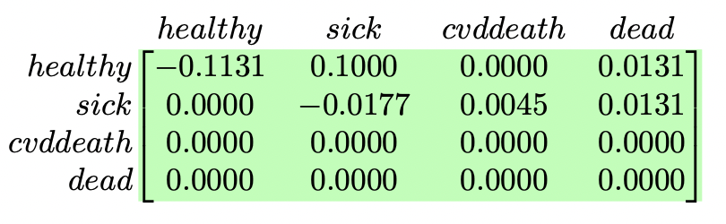

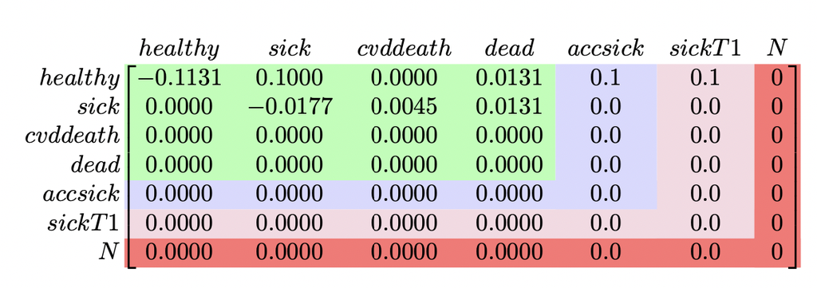

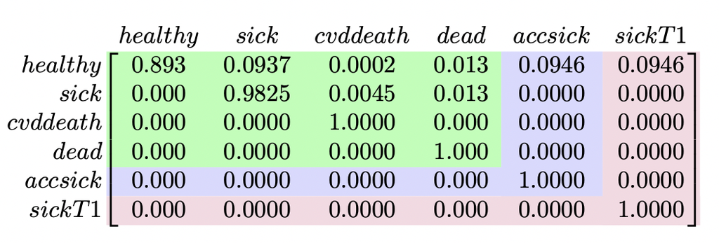

### Tunnel states

We will create a T1 state for tracking tunnels and allow exit from due to external death. This requires us to have a recieving bucket for these external risks ‘N’ for NULL so as not to disturb the balance of the Markov.

m = number of primary health states

1. Create m x m rate matrix R with initial cell values of 0
2. Fill in off-diagonal elements per parameters
3. Diagonal of R is negative row sum of off-diagonal elements
4. Add accumulator columns and rows as 0s. Call this new matrix R_
5. Fill in appropriate accumulator transition rates in R_
6. Add in tunnel states as new columns and rows
7. Add an additional “N” (NULL) state as recieving bucket external risks (e.g., background mortality) that can occur while in the tunnel so as not to disturb the balance of the Markov.
8. Take matrix exponential of R_ to obtain M_, the initial embedded transition probability matrix
9. Make edits to R_ to reflect tunnel state activity.
- Since it is possible to exit the tunnel for background mortality reasons, add the total background mortality

```r
starting_age = 40

markov_rate_matrices<- function(t)
{
  lapply(t, function(tt){

   current_age <- min(tt + starting_age - 1,max(lt_$age))

   r_death <- HP2(current_age, params$cause_deleted)$hx
   r_cause <- lt_ %>% filter(age==current_age) %>% pull(mi)

    x <- matrix(c(0.0, params$r_HS, 0.0, r_death,
                  0.0, 0.0, r_cause, r_death,
                  0.0, 0.0, 0.0, 0.0,
                  0.0, 0.0, 0.0, 0.0),
           nrow=4,
           ncol=4,
           byrow=TRUE,
           dimnames=list(c("healthy", "sick","cvddeath","dead"),
                         c("healthy", "sick","cvddeath","dead")))

    diag(x) <- -rowSums(x)
    x
  })
}

non_markov_rate_matrices <- function(t)
{
  markov     <- markov_rate_matrices(t)
  non_markov <- list()
  for(i in t)
  {
    # Expand matrix
    non_markov[[i]] <- cbind(markov[[i]],     matrix(rep(0, 4*3), nrow=4))
    non_markov[[i]] <- rbind(non_markov[[i]], matrix(rep(0, 3*7), nrow=3))
  }


  lapply(non_markov, function(m){
    # Put in State Names
    rownames(m) <- c("healthy", "sick", "cvddeath", "dead", "accsick", "sickT1", "N")
    colnames(m) <- c("healthy", "sick", "cvddeath", "dead", "accsick", "sickT1", "N")

    # Define Accumulator
    m["healthy", "accsick"] <- m["healthy", "sick"]

    # Define Tunnel state entry
    m["healthy", "sickT1"]  <- m["healthy", "sick"]

    m  # Note: Tunnel states are not fully defined at this point.
  })

}
```

Next we embed the non-Markovian matrices into the time step and finish the definition of the tunnel states in the probability space.

```r
transition_prob <- function(t,h=1)
{
  # Embed the matrices into the timesteps
  tp <- lapply(non_markov_rate_matrices(t), function(m) expm(m*h))

  lapply(tp, function(m)
  {
    # It is possible to exit tunnel to external risk of death
    m["sickT1", "N"]  <- m["healthy", "cvddeath"] + m["healthy", "dead"]
    m["sickT1", "sickT1"] <- 0  # Cannot remain in tunnel

    # last state in the tunnel is a terminal state
    m["sickT1", "N"]  <- 1

    # Note: At this point, the "N" state could be stripped as it was
    #       only required for the embedding, and serves no other purpose
    #       at this point

    states <- c("healthy", "sick", "cvddeath", "dead", "accsick", "sickT1")
    m[states, states]
  })
}
```

# 5. Backwards Conversion

Using the model in Table 2.2 pg.32, from “Decision Modelling for Health Economic Evaluation” by A Briggs, K Claxton and M Sculpher. Oxford, 2006.

```r
m_P <- matrix(c(0.721, 0.202, 0.067, 0.010,
                0.000, 0.581, 0.407, 0.012,
                0.000, 0.000, 0.750, 0.250,
                0.000, 0.000, 0.000, 1.000),
              nrow=4, byrow=TRUE,
              dimnames=list(c("A", "B", "C", "D"),
                            c("A", "B", "C", "D")))
m_P
```

```
      A     B     C     D
A 0.721 0.202 0.067 0.010
B 0.000 0.581 0.407 0.012
C 0.000 0.000 0.750 0.250
D 0.000 0.000 0.000 1.000
```

The theoretical approach requires computation of the eigenvalues of the matrix, and then correction along the way for various numerical errors to derive the generator matrix of rates. The observed statistical error from a stochastic process in general create a situation in which the Q-matrix is not derivable theoretically resulting in negative probabilities. Finding the closest generator matrix can be done using Higham’s 2008 method from `Functions of Matrices: Theory and Computation’ with extra balancing options from Stadelmann’s thesis.

```r
library(markovchain)

R <- transition2Generator(m_P)
rownames(R) <- c("A", "B", "C", "D")
colnames(R) <- c("A", "B", "C", "D")
R
```

```
         A       B          C         D
A -0.32712  0.3115  0.0024395  0.013181
B  0.00000 -0.5430  0.6148890 -0.071884
C  0.00000  0.0000 -0.2876821  0.287682
D  0.00000  0.0000  0.0000000  0.000000
```

Note: this is the closest Markov model allowing any transition. There are still transitions from A->C and A->D. Notably B->D occurs at a negative rate. If D were representing an absorbing state, e.g. Death, then this would represent a physical impossibility, as this negative rate represents D -> B.

## Demonstrate that the embedded (new) transition probability matrix successfully recreates the original transition probability matrix and results.

Let’s double check it recapitulates the original rates.

```r
round(expm(R),3)
```

```
4 x 4 Matrix of class "dgeMatrix"
      A     B     C     D
A 0.721 0.202 0.067 0.010
B 0.000 0.581 0.407 0.012
C 0.000 0.000 0.750 0.250
D 0.000 0.000 0.000 1.000
```

## An assumed model

If one were to assume that all transitions were forward , i.e. A->B->C->D the best approach would be to fit the generator matrix directly from raw data (there are many statistical Markov and ordinal data fitting models). Without the raw data available, an ad-hoc method to minimize squared error against the original under the 3 rate constraint does a decent job of recapitulating the original transition probabilities.

```r
init  <- c(1/3, 1/3, 1/3, 0)
step1 <- init %*% m_P
m_3r <- function(r)
    matrix(c(-r[1],  r[1],      0,    0,
                 0, -r[2],   r[2],    0,
                 0,     0,  -r[3], r[3],
                 0,     0,      0,   0), nrow=4, byrow=TRUE)
r.est <- optim((-diag(R))[1:3],
      lower=c(0.1, 0.1, 0.1),
      method="L-BFGS-B",
      function(r) {
      sum( ((init %*% expm(m_3r(r))) - step1)^2 )
})$par
m_3r(r.est)
```

```
         [,1]     [,2]     [,3]    [,4]
[1,] -0.32708  0.32708  0.00000 0.00000
[2,]  0.00000 -0.55796  0.55796 0.00000
[3,]  0.00000  0.00000 -0.24145 0.24145
[4,]  0.00000  0.00000  0.00000 0.00000
```

```r
round(expm(m_3r(r.est)),3)
```

```
4 x 4 Matrix of class "dgeMatrix"
      [,1]  [,2]  [,3]  [,4]
[1,] 0.721 0.211 0.063 0.006
[2,] 0.000 0.572 0.376 0.052
[3,] 0.000 0.000 0.785 0.215
[4,] 0.000 0.000 0.000 1.000
```

Now let’s replicate the monotherapy strategy results from the original.

```r
params_hiv <-
  list(
    R = R,
    dmca =   1701 , # Direct medical costs associated with state A
    dmcb =   1774 , # Direct medical costs associated with state B
    dmcc =   6948 , # Direct medical costs associated with state C
    ccca =   1055 , # Community care costs associated with state A
    cccb =   1278 , # Community care costs associated with state B
    cccc =   2059 , # Community care costs associated with state C
    cAZT =   2278 , # Zidovudine drug cost
    cLam =   2087 , # Lamivudine drug cost
    RR    =  0.509, # Treatment effect (RR)
    cDR  =  0.06,   # Annual discount rate - costs (%)
    oDR  =  0       # Annual discount rate - benefits (%)
  )

starting_age = 40

markov_rate_matrices <- function(t)
{
  lapply(t, function(tt) {
    current_age <- min(tt + starting_age - 1, max(lt_$age))

    # r_death <- HP2(current_age, params$cause_deleted)$hx
    # r_cause <- lt_ %>% filter(age==current_age) %>% pull(mi)

    x <- params_hiv$R

    diag(x) <- 0
    diag(x) <- -rowSums(x)
    x
  })
}

transition_prob <- function(t,h=1)
{
  # Embed the matrices into the timesteps
  tp <- lapply(markov_rate_matrices(t), function(m) expm(m*h))

}

Y <- t(c(A = 1, B = 0, C = 0, D = 0))

res_mono <- do.call(rbind, lapply(transition_prob(1:20), function(tp) {
  Y <<- Y %*% tp
}))

res_mono <- rbind(
  c(A = 1, B = 0, C = 0, D = 0),
  res_mono
)

res_mono <- round(res_mono,3)

payoff_health  = matrix(c(1,1,1,0),byrow=TRUE,ncol=1,dimnames=list(c("A","B","C","D"),c("qaly")))
qaly_mono <- as.matrix(res_mono[-1,]) %*% payoff_health
qaly_disc_mono <- qaly_mono / (1 + params_hiv$oDR)^c(1:(nrow(res_mono)-1))

payoff_cost_mono <- with(params_hiv,matrix(c(dmca + ccca + cAZT,
                        dmcb + cccb + cAZT,
                        dmcc + cccc + cAZT,
                        0)))
cost_mono <- as.matrix(res_mono[-1,]) %*% payoff_cost_mono %>% round(.,0)
cost_disc_mono <- cost_mono / (1 + params_hiv$cDR)^c(1:(nrow(res_mono)-1))


sum(qaly_disc_mono)
```

```
[1] 7.974
```

```r
sum(round(cost_disc_mono,0))
```

```
[1] 44589
```

This compares favorably to the textbook answer, which is 7.99 for QALYs and £44,663 for costs. The main differences seem to be rounding in the Excel answer within the textbook.

# 6. Changing Countries or Contexts

Rather than have a static death rate, let’s swap in secular mortality from several different countries and regions.

```r
tibble::tribble(
  ~code, ~country,
        "AUS",                              "Australia",
        "AUT",                               "Austria",
        "BLR",                               "Belarus",
        "BEL",                               "Belgium",
        "BGR",                              "Bulgaria",
        "CAN",                                "Canada",
        "CHL",                                 "Chile",
        "CZE",                        "Czech Republic",
        "DNK",                               "Denmark",
        "EST",                               "Estonia",
        "FIN",                               "Finland",
     "FRATNP",             "France (total population)",
     "FRACNP",          "France (civilian population)",
     "DEUTNP",            "Germany (total population)",
      "DEUTE",                        "Germany (east)",
      "DEUTW",                        "Germany (west)",
        "GRC",                                "Greece",
        "HUN",                               "Hungary",
        "ISL",                               "Iceland",
        "IRL",                               "Ireland",
        "ISR",                                "Israel",
        "ITA",                                 "Italy",
        "JPN",                                 "Japan",
        "LVA",                                "Latvia",
        "LTU",                             "Lithuania",
        "LUX",                            "Luxembourg",
        "NLD",                           "Netherlands",
     "NZL_NP",        "New Zealand (total population)",
     "NZL_MA",        "New Zealand (Maori population)",
     "NZL_NM",    "New Zealand (non-Maori population)",
        "NOR",                                "Norway",
        "POL",                                "Poland",
        "PRT",                              "Portugal",
        "RUS",                                "Russia",
        "SVK",                              "Slovakia",
        "SVN",                              "Slovenia",
        "ESP",                                 "Spain",
        "SWE",                                "Sweden",
        "CHE",                           "Switzerland",
        "TWN",                                "Taiwan",
     "GBR_NP",                        "United Kingdom",
    "GBRTENW",    "England & Wales (total population)",
    "GBRCENW", "England & Wales (civilian population)",
    "GBR_SCO",                              "Scotland",
    "GBR_NIR",                      "Northern Ireland",
        "USA",                                "U.S.A.",
        "UKR",                               "Ukraine"
    ) %>%
kable() %>%
  kable_styling()
```

| code | country |
| --- | --- |
| AUS | Australia |
| AUT | Austria |
| BLR | Belarus |
| BEL | Belgium |
| BGR | Bulgaria |
| CAN | Canada |
| CHL | Chile |
| CZE | Czech Republic |
| DNK | Denmark |
| EST | Estonia |
| FIN | Finland |
| FRATNP | France (total population) |
| FRACNP | France (civilian population) |
| DEUTNP | Germany (total population) |
| DEUTE | Germany (east) |
| DEUTW | Germany (west) |
| GRC | Greece |
| HUN | Hungary |
| ISL | Iceland |
| IRL | Ireland |
| ISR | Israel |
| ITA | Italy |
| JPN | Japan |
| LVA | Latvia |
| LTU | Lithuania |
| LUX | Luxembourg |
| NLD | Netherlands |
| NZL_NP | New Zealand (total population) |
| NZL_MA | New Zealand (Maori population) |
| NZL_NM | New Zealand (non-Maori population) |
| NOR | Norway |
| POL | Poland |
| PRT | Portugal |
| RUS | Russia |
| SVK | Slovakia |
| SVN | Slovenia |
| ESP | Spain |
| SWE | Sweden |
| CHE | Switzerland |
| TWN | Taiwan |
| GBR_NP | United Kingdom |
| GBRTENW | England & Wales (total population) |
| GBRCENW | England & Wales (civilian population) |
| GBR_SCO | Scotland |
| GBR_NIR | Northern Ireland |
| USA | U.S.A. |
| UKR | Ukraine |

```r
#hmd.ger <- demography::hmd.mx("DEUTNP",username = "", password = "", "")
#write_rds(hmd.ger,file=here("_sandbox/mortality/germany-life-table.rds"))

#hmd.pol <- demography::hmd.mx("POL",username = "", password = "", "POL")
#write_rds(hmd.pol,file=here("_sandbox/mortality/poland-life-table.rds"))
```

## Fit a mortality model to German life-table data and use the mortality rate from this model to estimate QALYs and costs

```r
# Fit the mortality model

min_age = 40
max_age = 99

hmd_ger <- read_rds(here("_sandbox/mortality/germany-life-table.rds"))

lt_ger <-  # Read in the U.S. life table data from the human mortality database.
  hmd_ger %>%
  lifetable(.,series = "total", years = mort_year) %>%
  as_tibble() %>%
  mutate_at(vars(lx,dx), function(x) x*N) %>%
  mutate(country = "USA") %>%
  mutate(age = x)

ages     <- lt_ger$x[lt_ger$x<=max_age & lt_ger$x>=min_age]
deaths   <- lt_ger$dx[lt_ger$x<=max_age & lt_ger$x>=min_age]
exposure <- lt_ger$lx[lt_ger$x<=max_age & lt_ger$x>=min_age]

hp_fit_ger <- MortalityLaw(
                x  = ages,
                Dx  = deaths,   # vector with death counts
                Ex  = exposure, # vector containing exposures
                law = "HP2",
                opt.method = "LF2")

params_hiv <- modifyList(params_hiv, list(mort = coef(hp_fit_ger),
                                          hr_mort = 2))
```

```r
markov_rate_matrices <- function(t)
{
  lapply(t, function(tt) {
    current_age <- min(tt + starting_age - 1, max(lt_$age))

    r_death <- params_hiv$hr_mort * HP2(current_age, params_hiv$mort)$hx

    x <- params_hiv$R
    x["A","D"] <- r_death

    diag(x) <- 0
    diag(x) <- -rowSums(x)
    x
  })
}

transition_prob <- function(t,h=1)
{
  # Embed the matrices into the timesteps
  tp <- lapply(markov_rate_matrices(t), function(m) expm(m*h))
  tp
}

Y <- t(c(A = 1, B = 0, C = 0, D = 0))

res_mono <- do.call(rbind, lapply(transition_prob(1:20), function(tp) {
  Y <<- Y %*% tp
}))

res_mono <- rbind(
  c(A = 1, B = 0, C = 0, D = 0),
  res_mono
)

res_mono <- round(res_mono,3)

payoff_health  = matrix(c(1,1,1,0),byrow=TRUE,ncol=1,dimnames=list(c("A","B","C","D"),c("qaly")))
qaly_mono <- as.matrix(res_mono[-1,]) %*% payoff_health
qaly_disc_mono <- qaly_mono / (1 + params_hiv$oDR)^c(1:(nrow(res_mono)-1))

payoff_cost_mono <- with(params_hiv,matrix(c(dmca + ccca + cAZT,
                        dmcb + cccb + cAZT,
                        dmcc + cccc + cAZT,
                        0)))
cost_mono <- as.matrix(res_mono[-1,]) %*% payoff_cost_mono %>% round(.,0)
cost_disc_mono <- cost_mono / (1 + params_hiv$cDR)^c(1:(nrow(res_mono)-1))

sum(qaly_disc_mono)
```

```
[1] 8.251
```

```r
sum(round(cost_disc_mono,0))
```

```
[1] 45928
```

# 7. Inpororating new evidence

# 8. Solving for PSA parameters

- [Source](https://www.johndcook.com/quantiles_parameters.pdf)
- [Another source](https://forum.effectivealtruism.org/posts/tvTqRtMLnJiiuAep5/how-to-determine-distribution-parameters-from-quantiles)
- [Excel Functions](https://docs.google.com/spreadsheets/d/1noozmyQvdqVXB8lH1JP1P7e6g-0FSV-9Q1EZS3Gh220/edit#gid=0)

## The new combination therapy arm has some new parameters with 95% CIs.

## Solve for the PSA distribution parameters

## How Do We Draw PSA Values?

| Parameter Type | Distribution |
| --- | --- |
| Probability | beta |
| Rate | gamma |
| Utility weight | beta |
| Right skew (e.g., cost) | gamma, lognormal |
| Relative risks or hazard ratios | lognormal |
| Odds Ratio | logistic |

### Normal Distribution

$$\sigma = \frac{x_2 - x_1}{\Phi^{-1}(p_2)-\Phi^{-1}(p_1)}
\tag{1}$$

$$\mu = \frac{x_1\Phi^{-1}(p_2)-x_2\Phi^{-1}(p_1)}{\Phi^{-1}(p_2)-\Phi^{-1}(p_1)}$$

```r
x1 <- qnorm(0.1,1.3,.2)
p1 <- 0.1

x2 <- qnorm(0.9,1.3,.2)
p2 <- 0.9

param_normal <- function(x1,x2,p1,p2) {
    sigma = (x2 - x1) / (qnorm(p2,0,1)-qnorm(p1,0,1)); sigma
    mu <- (x1*qnorm(p2,0,1)-x2*qnorm(p1,0,1))/(qnorm(p2,0,1)-qnorm(p1,0,1)); mu

    c("mu" = mu, "sigma" = sigma)
}
```

### Gamma Distribution

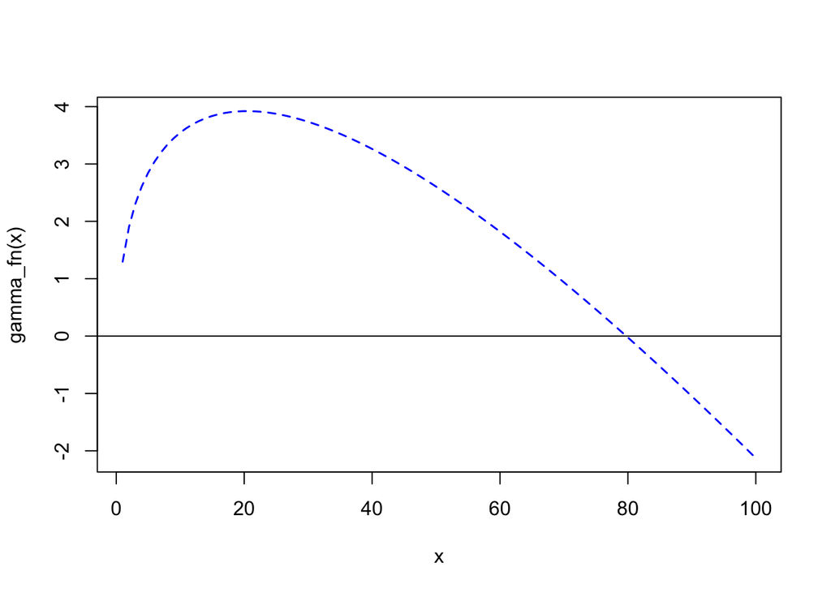

```r
x1 <- 0.6
x2 <- 0.8
p1 <- 0.1
p2 <- 0.9

gamma_fn <- function(alpha) {
    x1*qgamma(p2,shape = alpha, scale =1) - x2 * qgamma(p1, shape = alpha, scale = 1)
}

calc_beta <- function(x1,p1,alpha) {
    x1 / qgamma(p1,alpha,1)
}

curve(gamma_fn, xlim = c(1,100), col = "blue", lwd = 1.5, lty=2)
abline(a=0,b=0)
```

```r
alpha_ <- uniroot(gamma_fn,c(70,85))$root; alpha_
```

```
[1] 79.748
```

```r
beta_ <- calc_beta(x1 = x1,  p1 = p1, alpha = alpha_); beta_
```

```
[1] 0.0087542
```

```r
# Check the answer
qgamma(0.1,shape = alpha_, scale = beta_)
```

```
[1] 0.6
```

```r
qgamma(0.9,shape = alpha_, scale = beta_)
```

```
[1] 0.8
```

```r
param_gamma <- function(x1,x2,p1,p2,range) {
    alpha_ <- uniroot(gamma_fn,range)$root; alpha_
    beta_ <- calc_beta(x1 = x1,  p1 = p1, alpha = alpha_); beta_

    c("alpha" = alpha_, "beta" = beta_)
}
param_gamma(x1= x1, x2 = x2, p1 = p1, p2 = p2, range = c(60,100))
```

```
     alpha       beta
79.7475577  0.0087542
```

### Beta Distribution

```r
# Source: https://stats.stackexchange.com/questions/112614/determining-beta-distribution-parameters-alpha-and-beta-from-two-arbitrary

x1 <- 0.6
x2 <- 0.8
p1 <- 0.1
p2 <- 0.9

# Logistic transformation of the Beta CDF.
f.beta <- function(alpha, beta, x, lower=0, upper=1) {
  p <- pbeta((x-lower)/(upper-lower), alpha, beta)
  log(p/(1-p))
}

# Sums of squares.
delta <- function(fit, actual) sum((fit-actual)^2)

# The objective function handles the transformed parameters `theta` and
# uses `f.beta` and `delta` to fit the values and measure their discrepancies.
objective <- function(theta, x, prob, ...) {
  ab <- exp(theta) # Parameters are the *logs* of alpha and beta
  fit <- f.beta(ab[1], ab[2], x, ...)
  return (delta(fit, prob))
}

x.p <- (function(p) log(p/(1-p)))(c(p1, p2))
start <- log(c(1e1, 1e1))
sol <- nlm(objective, start, x=c(x1,x2), prob=x.p, lower=0, upper=1, typsize=c(1,1), fscale=1e-12, gradtol=1e-12)
params <- exp(sol$estimate); params
```

```
[1] 23.707 10.031
```

```r
qbeta(p = c(p1, p2), params[1], params[2])
```

```
[1] 0.6 0.8
```

# 9. Simulating PSA values from copulas

```r
######################################
## Option 1: Cholesky Decomposition
######################################
# Source: Coping with Copulas Sec 5.1

# 1. Define the correlation matrix
  rho <- 0.6
  sigma <- matrix(c(1,rho,rho,1),nrow = 2, byrow=TRUE)

# 2. Perform a cholesky decomposition
  A = chol(sigma)

# 3. Generate iid standard normal pseudo random variables
  tildeY0 <- rnorm(n = 1e6, mean = 0, sd = 1)
  tildeY1 <- rnorm(n = 1e6, mean = 0, sd = 1)
  tildeY <- cbind(tildeY0,tildeY1)

  # Collect them
  tildeY <- tildeY %*% A

# Use the standard normal disribution function to return the quantiles
  U <- pnorm(tildeY)

# Use the inverse distribution function to return the values
  Y <- U
  Y[,1] <- qpois(U[,1],lambda = 10)
  Y[,2] <- qpois(U[,2],lambda = 12)

# Confirm the correct correlation
cor(Y[,1],Y[,2])
```

```
[1] 0.59401
```

```r
##########################
## Option 2: Use MVRNORM
##########################
U_ <- pnorm(mvrnorm(n = 1e6, Sigma = sigma, mu = c(0,0)))
Y_ <- U_
Y_[,1] <- qpois(U_[,1],lambda = 10)
Y_[,2] <- qpois(U_[,2],lambda = 12)

cor(Y_[,1],Y_[,2])
```

```
[1] 0.59384
```

## Simulate direct medical care and community care costs for each state using copulas.

```r
rho <- 0.6
sigma <- matrix(c(1,rho,rho,1),nrow = 2, byrow=TRUE)

U_ <- pnorm(mvrnorm(n = 1e3, Sigma = sigma, mu = c(0,0)))
Y_ <- U_
Y_[,1] <- qpois(U_[,1],lambda = 10)
Y_[,2] <- qpois(U_[,2],lambda = 12)

cor(Y_[,1],Y_[,2])
```

```
[1] 0.58926
```